# P2 - Approved Building Permits | Austin, TX | 2023

Arun Mahadevan Sathia Narayanan | as235872 | arunmsnarayanan@utexas.edu

Date Published: 2024-12-07

[figure not shown]

The construction of the Google Sailboat Building. (Source: https://i.redd.it/dh75zlho59o71.jpg)

# **1. Introduction**

Population – it’s a very important statistic to measure. And lately, we can see a huge incoming population to Texas, especially Austin. In fact, in 2020, the measured population was **965,827**, with the estimated population in 2024 being **984,567**, nearly a *2%* increase in population.

The data was collection from [HERE](https://data.austintexas.gov/Building-and-Development/Building-Permits-Issued-in-2015/ayav-qckq), the City of Austin Data Portal. By simply changing the `Calendar Year Issued` date to be *equals 2023*, I was able to retrieve the csv data.

From the data, I will be investigating the following:

- The **zip codes** that appears most frequently
- What kinds of **work** were done often
- **When** were most projects *approved*
- **When** the projects were *completed*
- During what **day of the week** most projects take place

Just to name a few…

# **2. Data Preparation**

I obtained the data by downloading the CSV file from the website.

Since the date columns were classified as *chr*, I had to turn them into *Date* columns.  
The date columns were as follows: **`Applied.Data`, `Issued.Date`, `Expires.Date`**, and **`Completed.Date`**.

I attempted to change the **Status.Date** column to be of type *Date*, but was encountering some issues in conversions, so I left it as is. This means that when performing analyses, this column cannot be worked on. I will rather rely on the **Status.Current** column to analyze the projects.

After the re-factoring of columns, The only columns to have `NA` values are the **`Completed.Date`** and **`Applied.Date`** columns. These `NA` values are important as the `Completed.Date` NA’s signify that the project is yet to be completed or the project was withdrawn and the `Applied.Date` NA’s signify that no one applied for the project but was just rather issued to be done (which could be the government issuing its own project).

The column names didn’t have to be changed (as the names are already quite descriptive and the only changes would be to remove the .’s from the names).

# **3. Variable Descriptions**

|  | Type | Description |
| --- | --- | --- |
| Permit.Class.Mapped | character | Type of Permit |
| Work.Class | character | Type of Work |
| Applied.Date | Date | Permit Application Date |
| Issued.Date | Date | Permit Issuance Date |
| Day.Issued | character | Day of Week Permit was Issued |
| Calendar.Year.Issued | integer | Calendar Year Permit was Issued |
| Fiscal.Year.Issued | integer | Fiscal Year Permit was Issued |
| Status.Current | character | Current Status of Project |
| Expires.Date | Date | Expiration Date of Project |
| Completed.Date | Date | Completion Date of Project |
| Original.Address.1 | character | Address of Project |
| Original.Zip | integer | Zip Code of Project |

# **4. Univariate Analyses**

I chose the 4 following variables to analyze:

- Work.Class
- Day.Issued
- Status.Current
- Original.Zip

### Work.Class

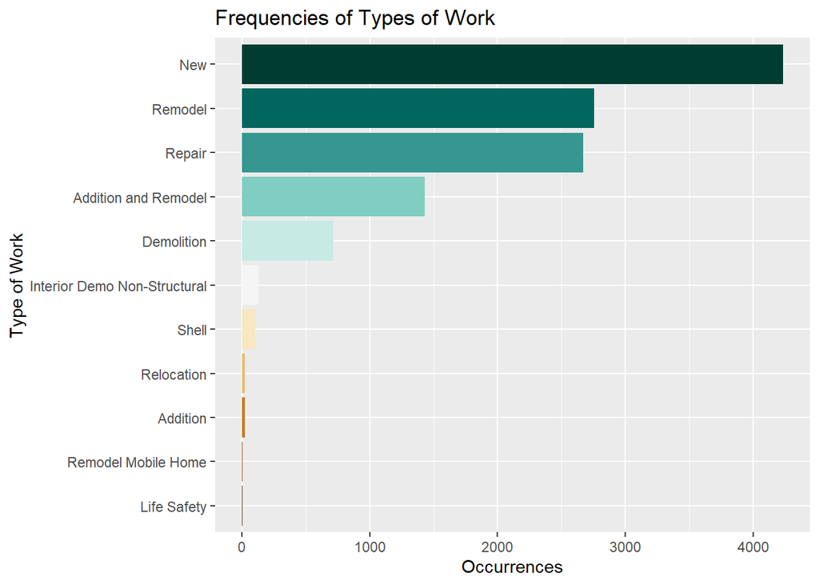

From the graph here, we can see that the types of work with the lowest number of occurrences are *Remodel Mobile Home* and *Life Safety*, with *Relocation* and *Addition* also having very few occurrences. The most amount of work happens when constructing something *New* or performing a *Remodel*.

### Day.Issued

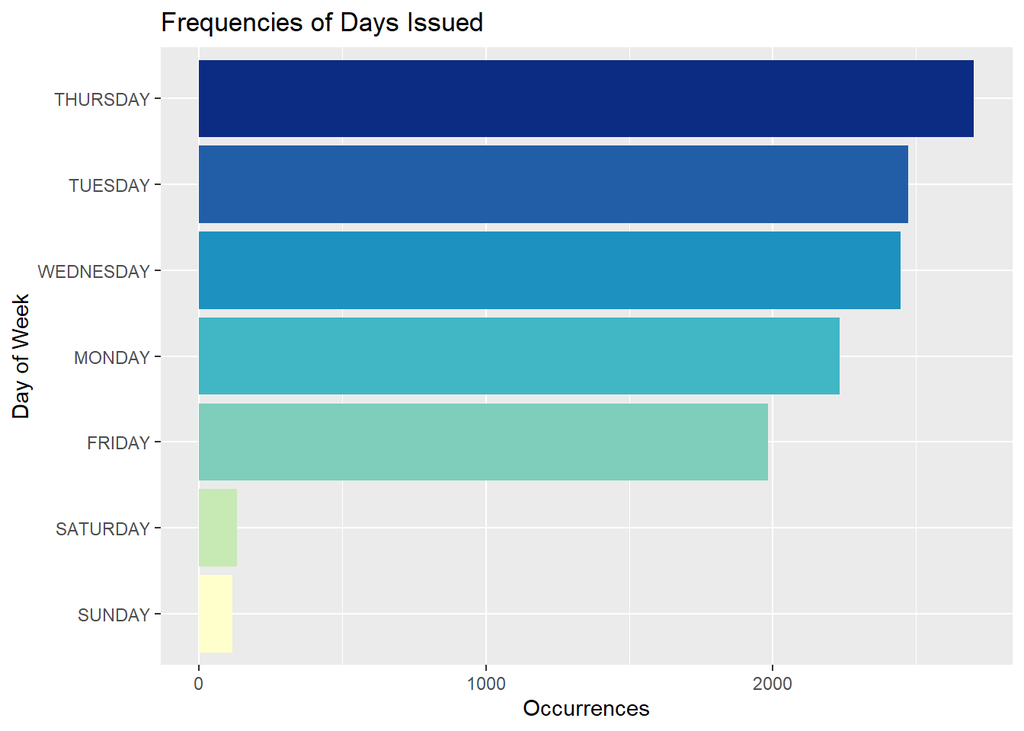

Seems like `Thursday` is the most popular day to issue a building permit, and `Sunday` is the least popular day. It is quite interesting to see that the weekends have the lowest number of occurrences, but it does make sense since the least amount of officials will be working on the weekends.

### Status.Current

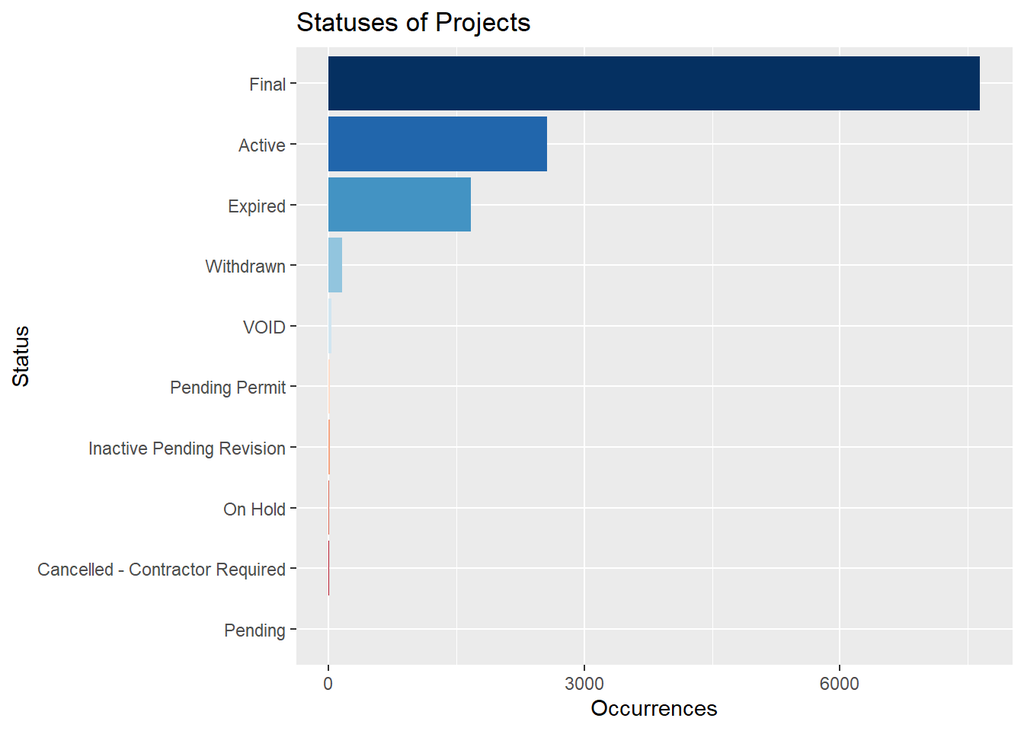

Analyzing the graph here, most of the projects that were approved did go to completion, as indicated by the large differences in occurrences between `Final` and the other statuses. A large amount of the approved permits (projects) remained `Active` or had `Expired`, which is interesting. Even though the permits were approved, some of the projects remained unfinished. This could be for several reasons.  
1) It could be that the project rolled over and was completed in 2024, and thus remained active.  
2) Some of the projects ended up needing more money or time necessary to be completed, therefore expiring.

### Original.Zip

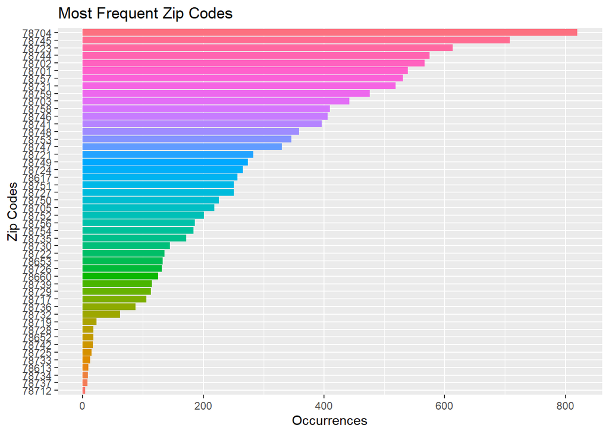

I think the analysis can be done pretty obviously here – just by looking at the graph, it is easy to say that most of the permits for construction were approved for the zip code 78704. 78704 is where Zilker Park, South Lamar, and St. Edward’s University are, making them high-population areas (just south of UT Austin). Because of its proximity to downtown Austin, it makes most sense for most building permits to be approved for that area. The second highest zip code occurrences happens in 78745, which is right below 78704.

# **5. Bivariate Analyses**

I chose the following variable relationships to analyze:

- Issued.Date - Applied.Date (Approval Time)
- Expires.Date - Issued.Date (Project Length)
- Approval Time vs. Project Length (Do longer projects take more approval time?)
- Work.Class vs. Project Length (How does the type of project relate to given time?)
- Work.Class vs. Day.Issued (How does the type of project relate to the day issued?)
- Work.Class vs. Status.Current (How does the type of project relate to it’s completion?)

### Approval Time

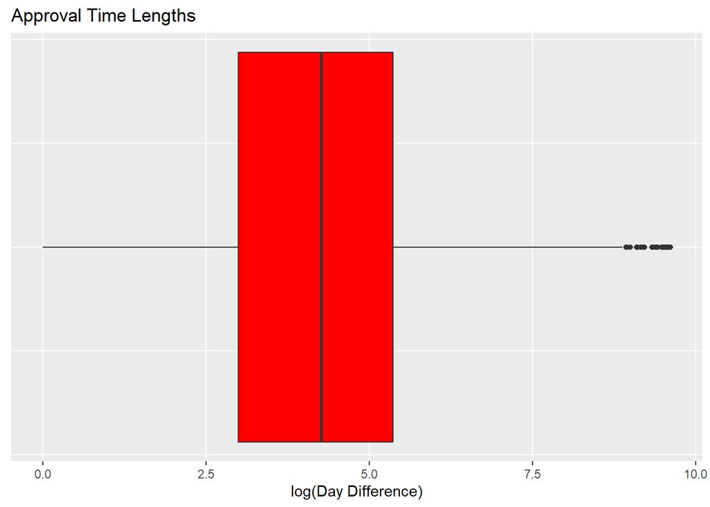

With the graph above, we can view time it took for the projects to be approved. Since the approval time for some of the projects took several years, there was data in the 15000s. This made the boxplot nearly unusable, and thus I chose to use `log` for convenient viewing.  
However, we do need the real data, and so the summary of the data is below:

```
##    Min. 1st Qu.  Median    Mean 3rd Qu.    Max.    NA's
##  -183.0    13.0    61.0   192.7   194.0 15048.0       1
```

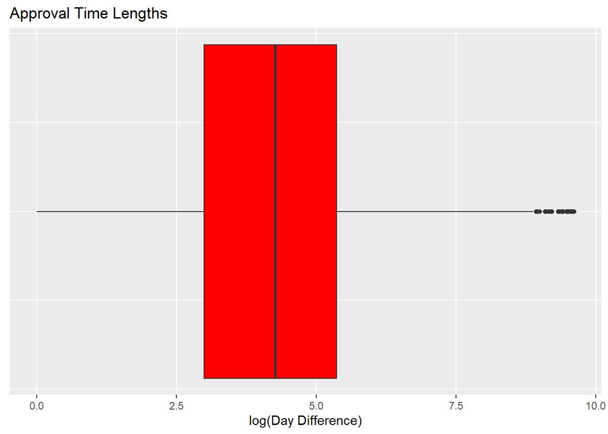

```
##    Min. 1st Qu.  Median    Mean 3rd Qu.    Max.    NA's
##  -183.0    13.0    61.0   192.7   194.0 15048.0       1
```

### Project Length

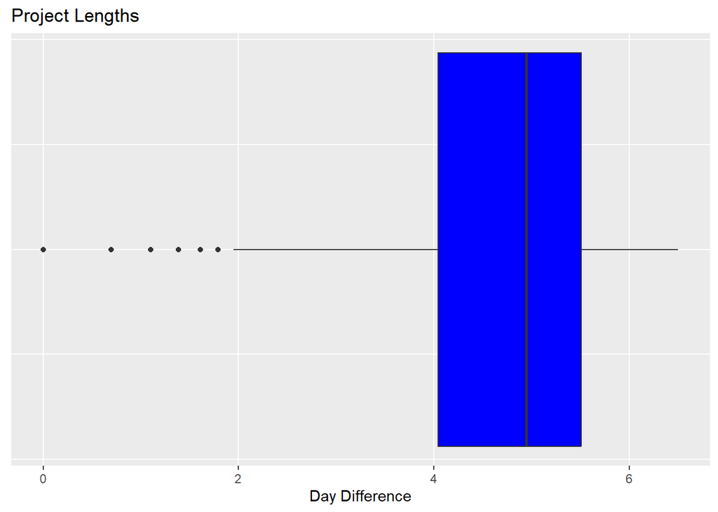

Similar to the last one, let’s view the summary:

```
##     Min.  1st Qu.   Median     Mean  3rd Qu.     Max.     NA's
## -14857.0     52.0    138.0    149.4    245.0    667.0     4276
```

Once again, we are getting the negative values.  
But before we attack the negatives, there’s a column from the summary labelled `NA's`, which is interesting. This is derived due to some of the projects (in this case, 4276) not having a completed date (thus set to NA) but having an issued date. When subtracting values from NA, the result ends up being, you guessed it, NA. The projects with statuses Active, Expired, and VOID all had NA completed dates, with each having 2561, 1669, and 33, respectively. These total up to 4263, because Withdrawn, Pending Permit, and On Hold all have their amount of NA’s (which total up to 13), giving us the 4276.

Let’s filter the negative and NA values out and view the graph and data.

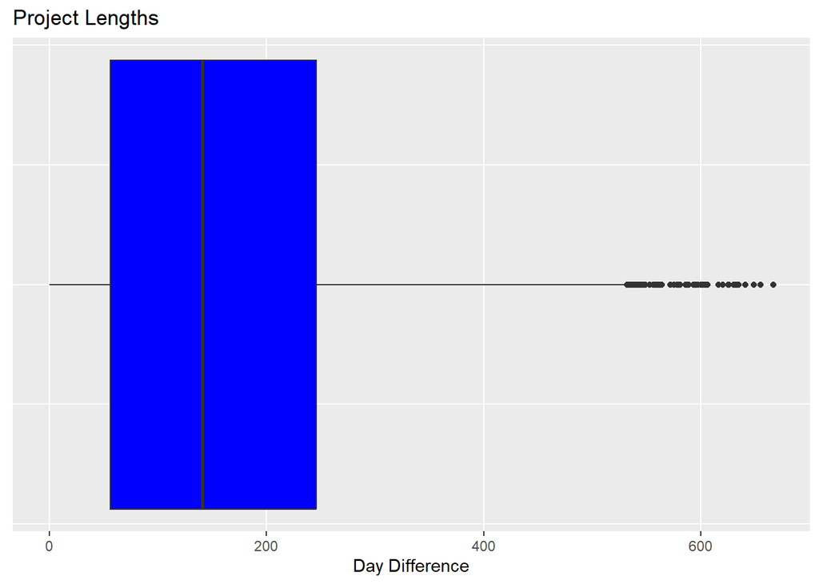

```
##    Min. 1st Qu.  Median    Mean 3rd Qu.    Max.
##     0.0    56.0   141.0   165.7   246.0   667.0
```

Now we can visualize that the average time it took for a project to be completed was 165 (nearly 166) days, with the maximum being 667 days. More than **75%** of the day differences are below 246 days.

For the sake of repetition, I will mutate the dataframe to have the above two as additional columns.

### Approval Time vs. Project Length

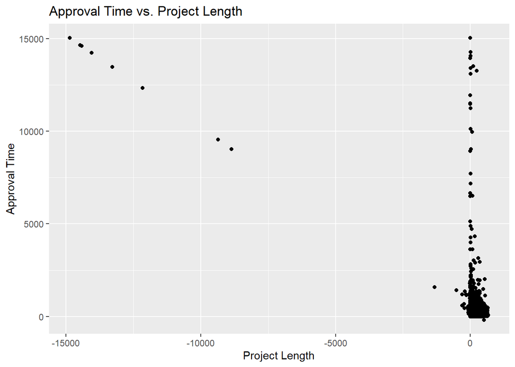

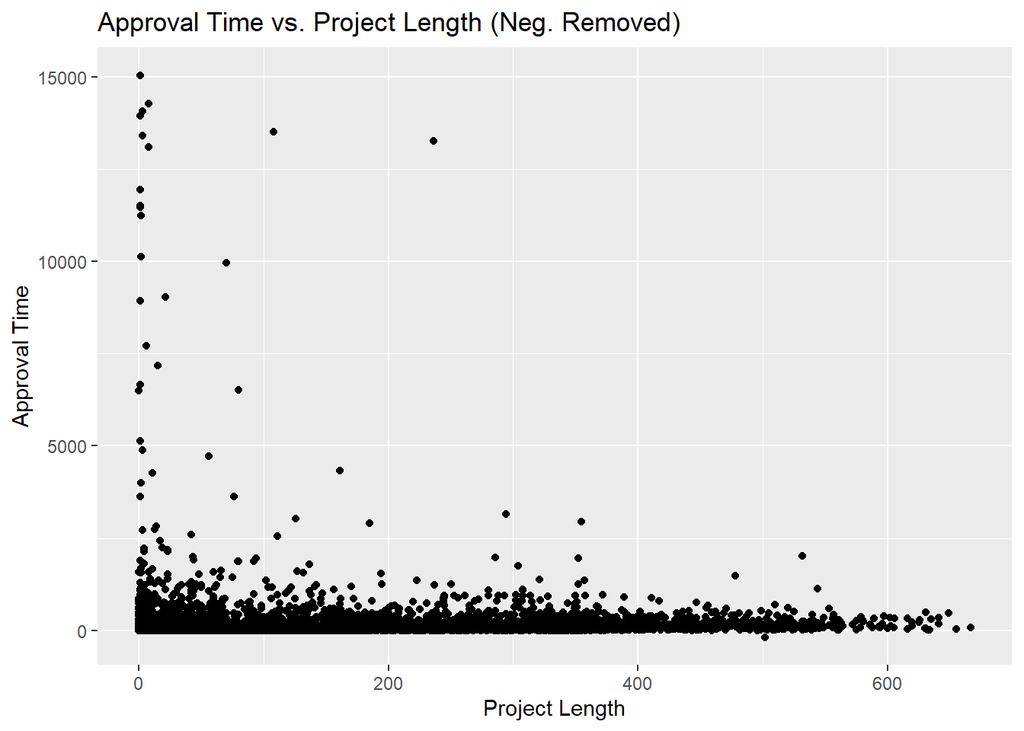

Looking at the graph, most of the cluster is below an Approval Time of 2500 days. But the question is how do these two relate? From previous analyses, we can know that the more horizontal/vertical a graph is, the less correlation the two variables are, and the graphs with a slope have a correlation. This graph is both horizontal and vertical, so let’s see how this turns out.

```
## [1] -0.04
```

Well, this graph shows a -0.04 correlation, which is a *Weak Negative* relationship. Anything with no correlation is bad enough, but this is worse! These two variables move in opposite directions - the longer the project length, the shorter the approval time (essentially, the graph is downward sloping rather than upward sloping). Thing is, it would be vital if the correlation was more negative than it is, but with -0.04, that’s basically nothing. In the end, it just means that these two variables have very little effect on each other, but the general trend is somewhat (very, very slightly) negative sloping.

### Work.Class vs. Project Length

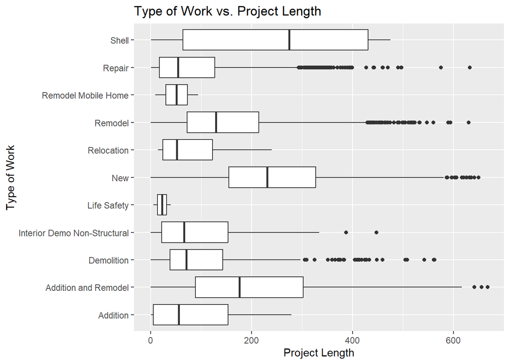

The type of work that had the largest median project length was `Shell`. `Shell` is a construction term used to describe the exterior and the core of the building (which would be walls, roofing, foundation, windows, etc.). In contrast, `Life Safety` had the lowest median project length. `Addition and Remodel` had the largest project length (which would be 667, as observed from the **Project Lengths** analysis). `New` had the second largest max, with `Repair` coming in third and `Remodel` coming in fourth. Interestingly, `Life Safety`, alongside having the lowest median project length (and maximum project length for that matter), also has the lowest number of occurrences. `New` has the most amount of occurrences.

### Work.Class vs. Day.Issued

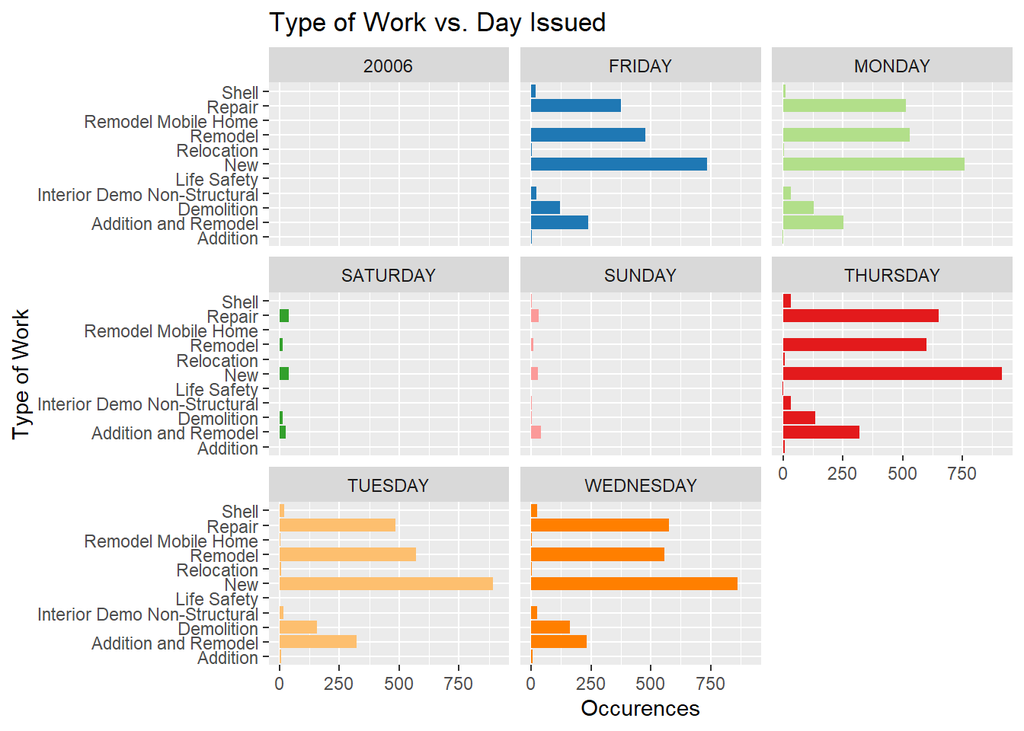

For the weekdays (M, T, W, Th, F), we can see that the `New` category leads in occurrences. On the weekends (Sat, Sun), due to the lower quantity of work being done, it’s harder to see which one really takes the lead, but on a high level, `New` takes the lead for Saturday and `Addition and Remodel` takes the lead on Sunday.  
One patterns of types of work is similar on Mondays, Tuesdays, and Fridays while another is similar on Wednesdays and Thursdays.  
The analysis we can perform here is simple: more work is assigned on weekdays than weekends. Since the pattern is quite similar for all weekdays, there would be no correlation between the type of work done and the day the project is issued on.

### Work.Class vs. Status.Current

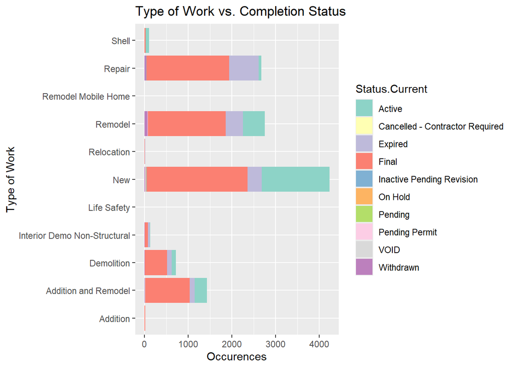

Here, we can see that a majority of the projects did end up going to completion, but even if the `New` column had the most amount of completed projects, it also had the largest amount of active projects. `Repair` had the largest amount of expired projects, and `Remodel` had the largest amount of withdrawn projects.

Seeing as how interesting it was to analyze the graphs before, let’s try to create a MULTIVARIATE plot, which has 3 variables compared against each other.

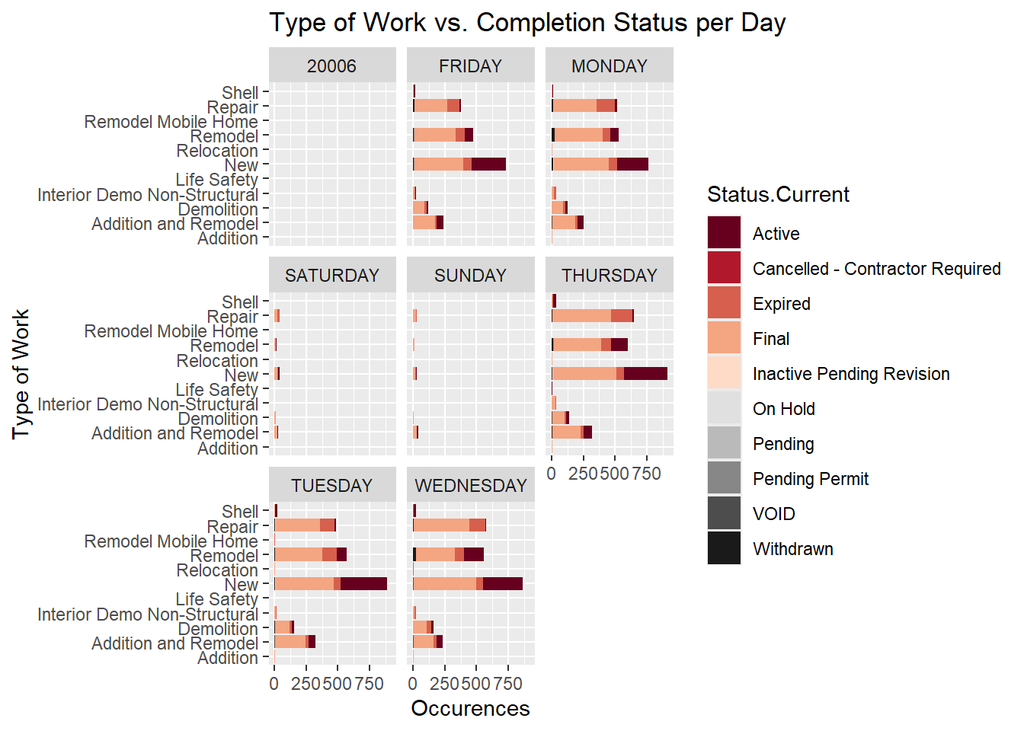

Above is the relationship between three variables: Work.Class, Status.Current, and Day.Issued. As seen, a majority of the projects were finalized, but a large proportion of them for each day remained active. Here, we are basically looking at the same data as the sixth analysis (Type of Work vs. Completion Status), but now we’ve split them up into days. Nevertheless, the pattern remains the same: the weekdays get a majority of the projects, with New being the highest for them all and the patterns of the data heights matching with other days.